# Final Report

Sere Williams, Heather Deel, Sunny Liu, Khum Thapa-Magar

12/13/2019

##### INTRODUCTION

When we loaded in the raw data, we found that a lot of categories kept showing up within different seasons. Were were then curious about the frequency of each of these different categories, and wondered what the top 5 categories were. During this investigation, we found that at the year 1998, there is a large drop in the prevalence of these top 5 categories, prompting more in depth analysis.

We were also curious about the “mythology” category, which was one of the more common categories, and wanted to explore that in more depth. To do this, we performed a key word search for popular gods ‘Zeus’ and ‘Athena’.

**Research questions**

Question 1: What are the top 5 categories in all seasons, and how often do these occur per year?

##### METHODS

**Data collection** Data were collected from GitHub: https://github.com/legacybass/Jeopardy. The original, tab delimited data was saved in our group GitHub repository.

**Data cleaning** Data were cleaned by separating the air date into day, year, and month columns to allow for usage of the year column. Unnecessary columns such as comments and notes were removed. The year 2019 was filtered out, and the group_by function was used to look at the occurrence of categories over each year. The data were then converted to all lowercase for consistency.

**Plotting top five categories** We visualized each of the top 5 categories using ggplot2. Within each year, the proportion of each of the categories was shown using a stacked bar chart.

**Software and packages** We used R free software version 3.6.0 for all of the analysis. R packages dplyr, ggplot2, stringr, tidyr, readr, lubridate, forcats, DT, plotly, knitr, and broom were used for analysis.

##### RESULTS

**Top 5 categories in all seasons**

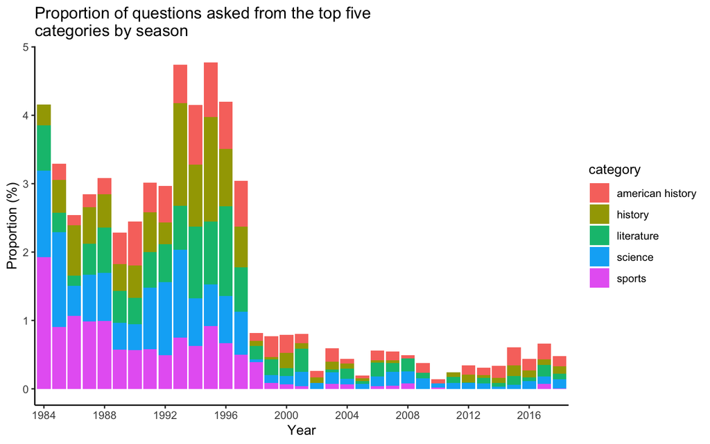

**Top five category before and after 1998**

As the table shows, two of the top five categories from all seasons are also in the top five categories from 1998-2018: american history and literature. Science appears at #6, however history and sports are not even in the top 10. From 1998-2018, history is the 31st most asked category and sports is 81st (not on the top 50 list).

Before & after, word origins, and potpourri are now in the top five. Note that these three categories were in the top 10 categories of all seasons.

| category | before_98 | after_98 |
| --- | --- | --- |
| sports | 574 | 127 |
| science | 553 | 292 |
| history | 513 | 196 |
| literature | 503 | 301 |
| world geography | 484 | 145 |

Statistical testing also showed the significant difference in the average number of questions asked before and after 1998 in the program.

| estimate | estimate1 | estimate2 | statistic | p.value | parameter | conf.low | conf.high | method | alternative |
| --- | --- | --- | --- | --- | --- | --- | --- | --- | --- |
| 313.2 | 525.4 | 212.2 | 7.856561 | 0.0003146 | 5.601601 | 213.9478 | 412.4522 | Welch Two Sample t-test | two.sided |

**Appearance of Zeus and Athena over seasons**

The plot shows that both Zeus and Athena consistently show up in either the answer or question over time, with Athena appearing ~20 times while Zeus appeared ~33 times. While neither appear at all in some years, in others they appear as many as 5 times, with the most popularity within the late 90s and early 2000s.

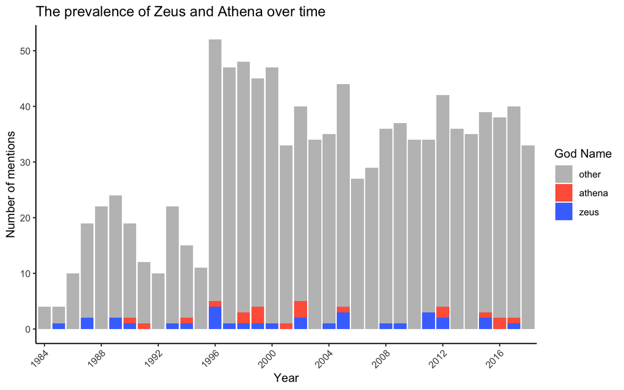

##### DISCUSSION

We found american history, history, literature, science, and sports were the top 5 categories asked in Jeopardy when analyzing all of the seasons.

The proportion of questions within each top top category also varied in each season. For example, questions within the sports category clearly dropped. An interesting trend was that there was a large drop in these top 5 categories after 1998. Although we are not sure why this occurred, it could be that Jeopardy was trying to make the show more interesting by adding new categories that could contain different types of questions. Furthermore, the reason could also have been to make the show more difficult if participants were too informed about the top 5 categories.

We found that Zeus and Athena consistently showed up within most seasons. They were most commonly found around the years 1996 to 2002. The plot shows that Zeus and Athena consistently show up in both the answer and question over time, with Athena appearing ~20 times while Zeus appeared ~33 times. This could be because Zeus is involved in more stories in mythology then Athena and thus appeared more often. The popularity around the late 1990s/early 2000s could coincide with movies about mythology that were released around that time, such as ‘The Odyssey’ and Disney’s ‘Hercules’.

##### CONCLUSION

American history, history, literature, science, and sports were the top 5 categories when analyzing all Jeopardy data.

There was clear drop in the relative proportion of questions within these top five categories after 1998.